# Stat 579 - Homework #4

9/18/2018

## Subsets and Visualizations: Movie Mojo

For this homework we are using the data set `mojo` from the classdata package. `mojo` constains data on box office revenue for movies based on the website https://www.boxofficemojo.com .

Run the following two commands to install the newest version of the package from github:

```r
library(devtools) # error? then run install.packages("devtools")
devtools::install_github("heike/classdata")
```

Check what is in the data set:

```r
library(classdata)
head(mojo)
```

```
##   TW LW                         Title Studio Weekend Gross % Change
## 1  1  1             Crazy Rich Asians     WB      21964345    -11.5
## 2  2  2                       The Meg     WB      10535459    -17.8
## 3  3  4 Mission: Impossible - Fallout   Par.       7032499    -13.0
## 4  4 22                     Searching   SGem       6066463   1460.4
## 5  5 NA              Operation Finale    MGM       6022758       NA
## 6  6  6    Disney's Christopher Robin     BV       5277955    -15.7
##   Theater Count Theater Change Average Total Gross Budget (in Million)
## 1          3865            339    5683   110691733                  30
## 2          3761           -270    2801   120521875                 130
## 3          2639           -413    2665   204379028                 178
## 4          1207           1198    5026     6574943                  NA
## 5          1818             NA    3313     7749853                  24
## 6          2925           -469    1804    85686823                  NA
##   Week                     Weekend Year WeekNo
## 1    3 August 31-September 2, 2018 2018     35
## 2    4 August 31-September 2, 2018 2018     35
## 3    6 August 31-September 2, 2018 2018     35
## 4    2 August 31-September 2, 2018 2018     35
## 5    1 August 31-September 2, 2018 2018     35
## 6    5 August 31-September 2, 2018 2018     35
```

```r
library(ggplot2)
```

1. Download the RMarkdown file with these homework instructions to use as a template for your work. Make sure to replace “Your Name” in the YAML with your name.
2. What is the difference between the variables `Week` and `WeekNo`? Describe in your words.

```r
str(mojo)
```

```
## 'data.frame':    31718 obs. of  15 variables:
##  $ TW                 : num  1 2 3 4 5 6 7 8 9 10 ...
##  $ LW                 : num  1 2 4 22 NA 6 7 3 8 5 ...
##  $ Title              : chr  "Crazy Rich Asians" "The Meg" "Mission: Impossible - Fallout" "Searching" ...
##  $ Studio             : chr  "WB" "WB" "Par." "SGem" ...
##  $ Weekend Gross      : num  21964345 10535459 7032499 6066463 6022758 ...
##  $ % Change           : num  -11.5 -17.8 -13 1460.4 NA ...
##  $ Theater Count      : num  3865 3761 2639 1207 1818 ...
##  $ Theater Change     : num  339 -270 -413 1198 NA ...
##  $ Average            : num  5683 2801 2665 5026 3313 ...
##  $ Total Gross        : num  1.11e+08 1.21e+08 2.04e+08 6.57e+06 7.75e+06 ...
##  $ Budget (in Million): num  30 130 178 NA 24 NA 51 40 15 50 ...
##  $ Week               : num  3 4 6 2 1 5 3 2 4 3 ...
##  $ Weekend            : chr  "August 31-September 2, 2018" "August 31-September 2, 2018" "August 31-September 2, 2018" "August 31-September 2, 2018" ...
##  $ Year               : num  2018 2018 2018 2018 2018 ...
##  $ WeekNo             : num  35 35 35 35 35 35 35 35 35 35 ...
```

```r
summary(mojo$Week)
```

```
##    Min. 1st Qu.  Median    Mean 3rd Qu.    Max.
##  -48.00    3.00    6.00   23.72   12.00  873.00
```

```r
summary(mojo$WeekNo)
```

```
##    Min. 1st Qu.  Median    Mean 3rd Qu.    Max.
##    1.00   14.00   26.00   26.14   38.00   53.00
```

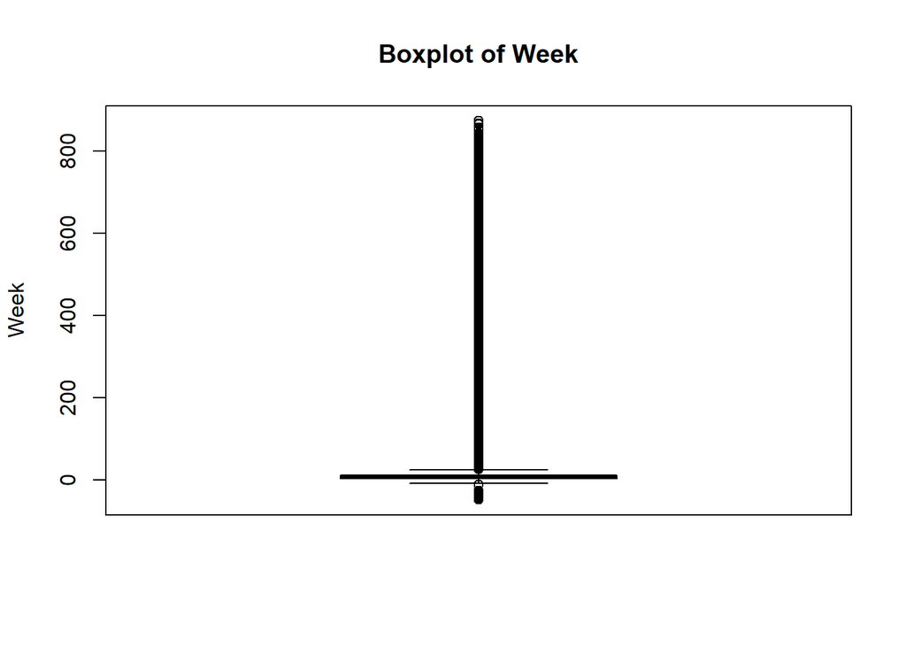

```r
boxplot(mojo$Week,main="Boxplot of Week", ylab="Week")
```

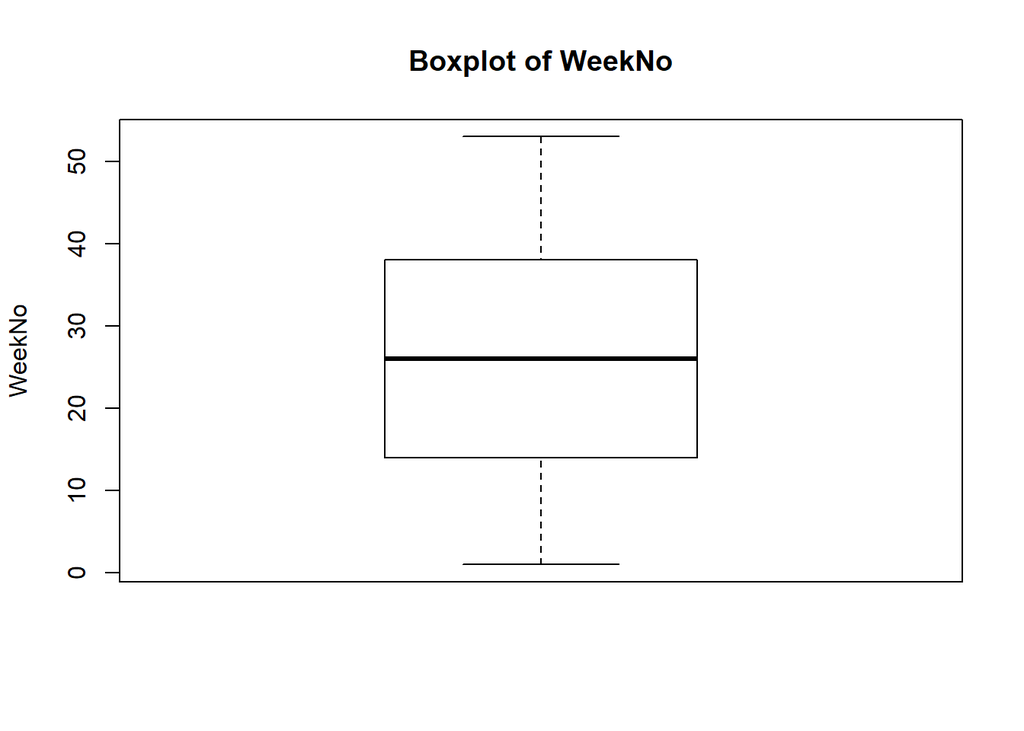

```r
boxplot(mojo$WeekNo,main="Boxplot of WeekNo", ylab="WeekNo")
```